# GLM para dados contínuos

Maria Carolina Pacheco

## 1 Introdução

Para esta etapa do relatório, vou usar dados de taxa de fagocitose de corais. Esses dados foram obtidos por meio de análise realizada com citometria de fluxo. E a taxa representa a proporção de fagócitos dentre todas as células analisadas do coral.

Os corais foram coletados durante uma onda de calor, então haviam corais com três estados de saúde diferentes:

- Saudáveis
- Fluorescentes (rosa)
- Branqueados

Além disso, os corais foram coletados em duas áreas diferentes: Recife raso (Rio do Fogo) e Poça de maré (Pirambúzios).

```r
#Abrindo meu banco de dados
fago <- read.csv("dados_scriptsR/fagocitose.csv", header = T, sep =";", dec = ".")

# Visualizando a estrutura dos dados
str(fago)
```

```
## 'data.frame':    30 obs. of  6 variables:
##  $ sample_name : chr  "23_05_24_1 B.fcs" "23_05_24_2 B.fcs" "23_05_24_3 B.fcs" "23_05_24_4 B.fcs" ...
##  $ origin      : chr  "tide" "tide" "tide" "tide" ...
##  $ ID          : int  1 2 3 4 5 6 7 8 9 10 ...
##  $ beads       : chr  "B" "B" "B" "B" ...
##  $ health      : chr  "healthy" "healthy" "healthy" "healthy" ...
##  $ phagocytosis: num  16.8 5 12.5 11.8 15.2 3.49 7.89 2.16 14 2.97 ...
```

```r
View(fago)

# Transformando as variáveis que vamos usar em fator
fago[, c("origin", "ID", "health")] <- lapply(fago[, c("origin", "ID", "health")], factor)
```

OBS.: Origin se refere ao local de coleta; Health se refere ao estado de saúde.

## 2 Análise exploratória

Vou começar a plotar os dados pra ter uma ideia da distribuição deles

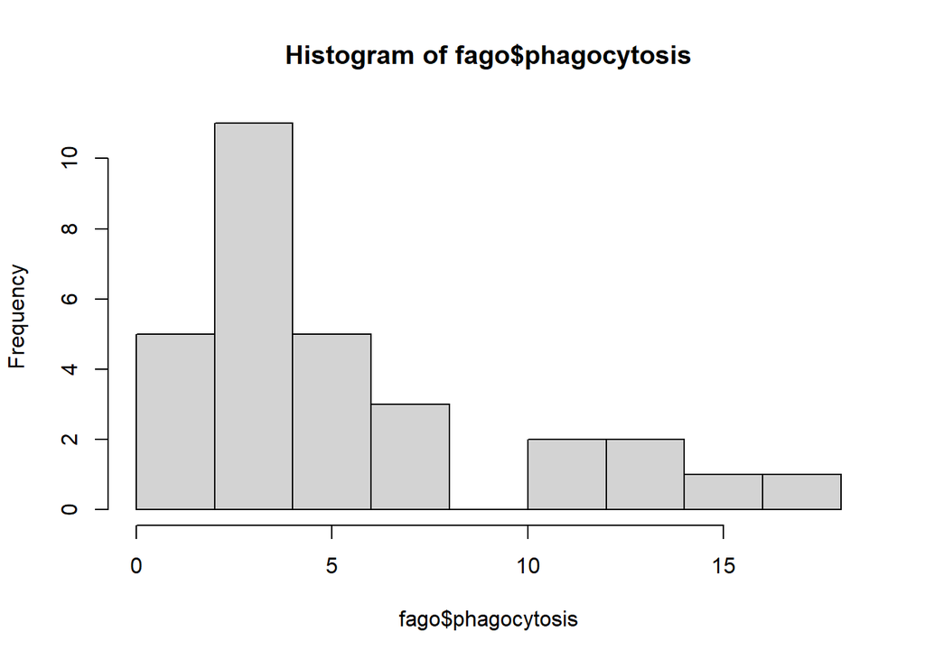

```r
# Visualizando graficamente
hist(fago$phagocytosis)
```

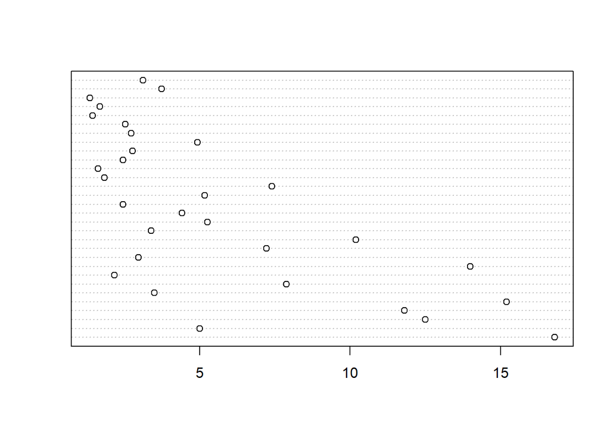

```r
dotchart(fago$phagocytosis)
```

```r
summary(fago$phagocytosis)
```

```
##    Min. 1st Qu.  Median    Mean 3rd Qu.    Max.
##   1.350   2.470   3.610   5.583   7.355  16.800
```

Os dados parecem ter uma assimetria à direita, mas não são zero-infalcionados. O valor mínimo da taxa de fagocitose foi 1.350 e, o máximo, 16.800. Vamos plotar agora a fagocitose com as variáveis preditoras.

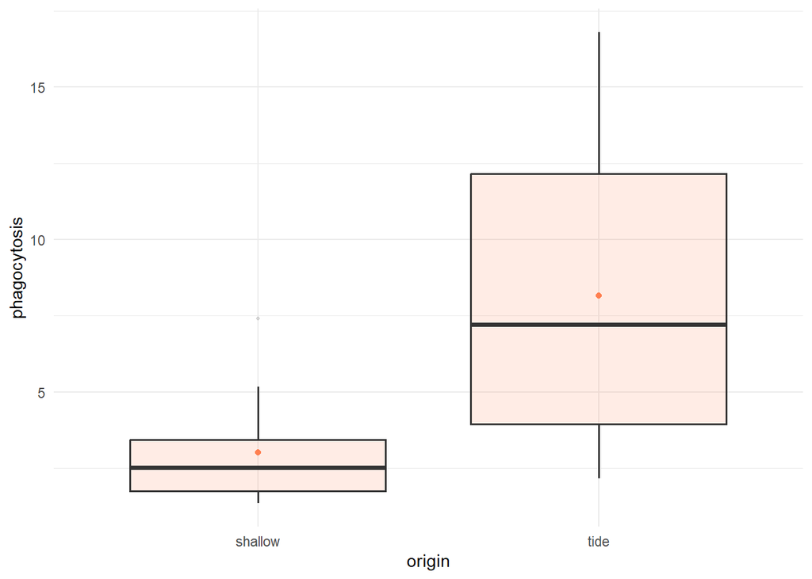

```r
# Enxergar a relação com a origem do coral
ggplot(fago, aes(x = origin, y = phagocytosis)) +
  #ggplot(dados, aes(x = Mes, y = log1p(BPUE))) +
  geom_boxplot(size = 0.7, fill = 'coral', alpha = 0.15) +
  stat_summary(fun = mean, geom="point", shape=19, size=1.5, color="coral") +
  theme_minimal()
```

Os corais da poça de maré parecem ter taxa de fagocitose maior que os corais do raso.

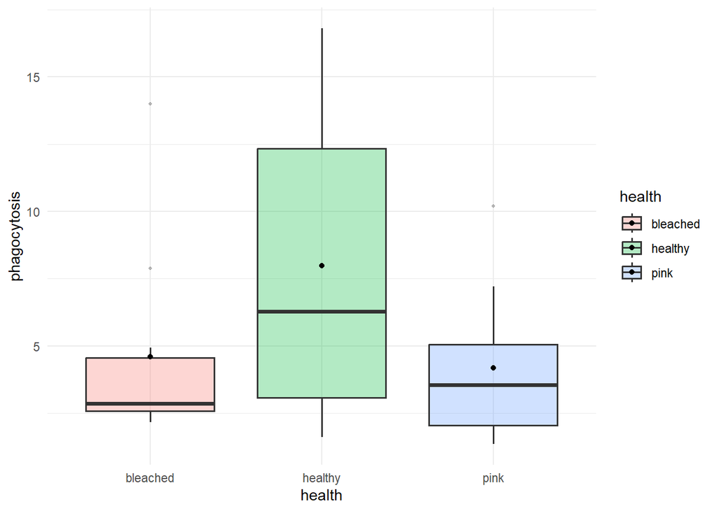

```r
# E agora a relação com o estado de saúde
ggplot(fago, aes(x = health, y = phagocytosis, fill= health)) +
  #ggplot(dados, aes(x = Mes, y = log1p(BPUE))) +
  geom_boxplot(size = 0.7, alpha = 0.30) +
  stat_summary(fun = mean, geom="point", shape=19, size=1.5) +
  theme_minimal()
```

Os corais saudáveis apresentam maior taxa de fagocitose quando comparamos com os branqueados e fluorescentes.

## 3 Hipóteses

A taxa de fagocitose é um proxy para a resposta imune dos corais. Espera-se que, diante do aquecimento da água do mar, os corais com uma resposta imune mais robusta sejam os que consigam se manter saudáveis. Por isso:

- Esperamos que taxa de fagocitose varie entre os corais com diferentes estados de saúde, de modo que os corais saudáveis apresentem maior fagocitose
- Esperamos que a taxa de fagocitose também varie entre ambientes distintos, sendo mais elevada na poça de maré, onde os corais são tipicamente mais resistentes ao estresse.

## 4 Análises e resultados

### 4.1 Montando o modelo

Vou fazer um modelo usando distribuição gama e outro usando lognormal, para ver qual se ajusta melhor.

```r
# Modelo Gama
mod_fago_gama <- glmmTMB(phagocytosis ~ origin + health,
                    family = Gamma(link = "log"),
                    data = fago)
# Modelo lognormal
mod_fago_log <- glmmTMB(phagocytosis ~ origin + health,
                         family = lognormal(link = "log"),
                         data = fago)
#Comparando os AICs
AIC(mod_fago_gama, mod_fago_log)
```

```
##               df      AIC
## mod_fago_gama  5 140.9689
## mod_fago_log   5 149.3406
```

O modelo que fizemos utilizando a distribuição gama teve o menor AIC, o que significa que explicou mais a variação dos nossos dados. Agora vamos checar o ajuste do modelo.

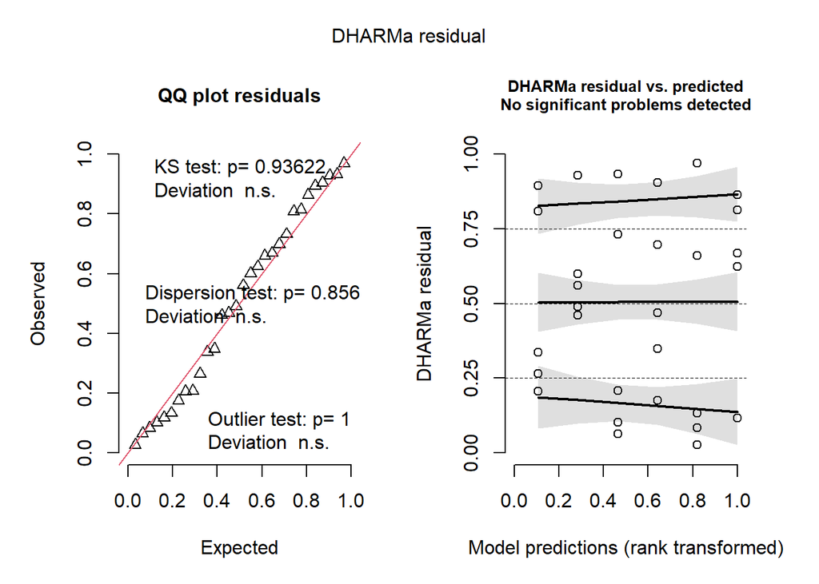

```r
#simulando os resíduos
res_gama <- simulateResiduals(mod_fago_gama, n=1000)

#plotando os resíduos
plot(res_gama) #ficou top
```

```r
check_model(mod_fago_gama)
```

```
## `check_outliers()` does not yet support models of class `glmmTMB`.
```

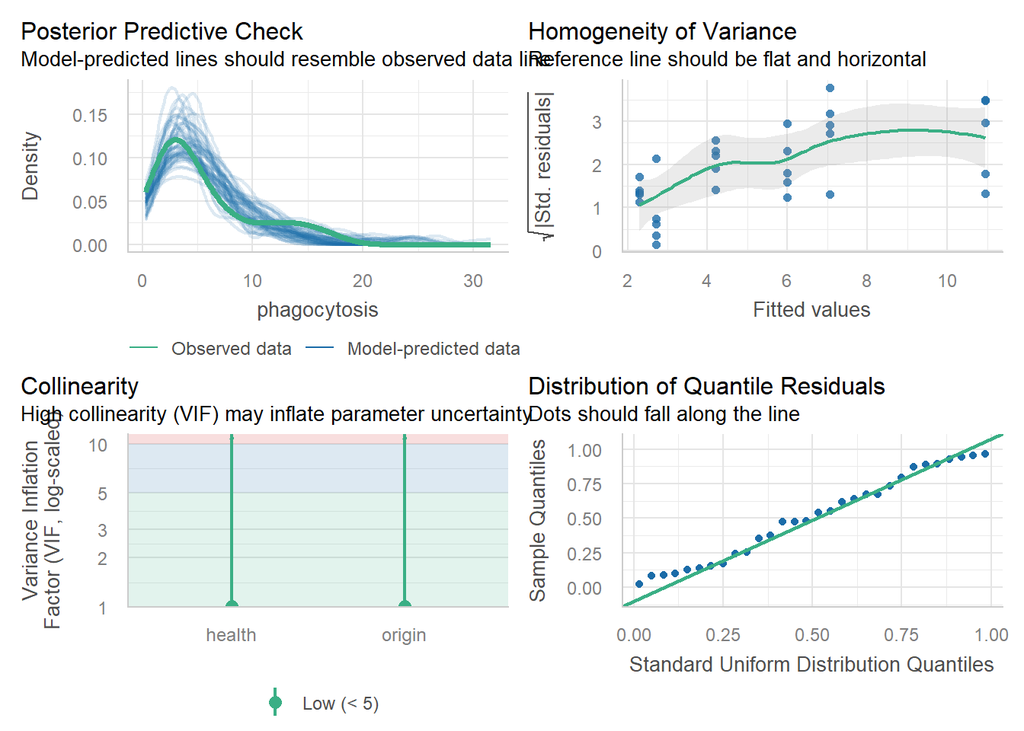

O modelo parece estar bem ajustado. O único gráfico que não ficou tão bom foi o de homgeneidade de variâncias, que não está tão linear e reto. Mas pode ser que esse problema esteja aparecendo por meus preditores serem categóricos e com poucos níveis.

Vamos ver os resultados do modelo

```r
summary(mod_fago_gama)
```

```
##  Family: Gamma  ( log )
## Formula:          phagocytosis ~ origin + health
## Data: fago
##
##       AIC       BIC    logLik -2*log(L)  df.resid
##     141.0     148.0     -65.5     131.0        25
##
##
## Dispersion estimate for Gamma family (sigma^2): 0.237
##
## Conditional model:
##               Estimate Std. Error z value Pr(>|z|)
## (Intercept)     0.9971     0.1722   5.791 7.01e-09 ***
## origintide      0.9581     0.1787   5.360 8.31e-08 ***
## healthhealthy   0.4379     0.2189   2.000   0.0454 *
## healthpink     -0.1635     0.2181  -0.749   0.4536
## ---
## Signif. codes:  0 '***' 0.001 '**' 0.01 '*' 0.05 '.' 0.1 ' ' 1
```

Além disso, com relação ao estado de saúde, vemos diferença somente do saudável em relação ao branqueado. Os corais saudáveis apresentam maior taxa de fagocitose.

Conseguimos visualizar esses resultados nos gráficos dos valores preditos a seguir:

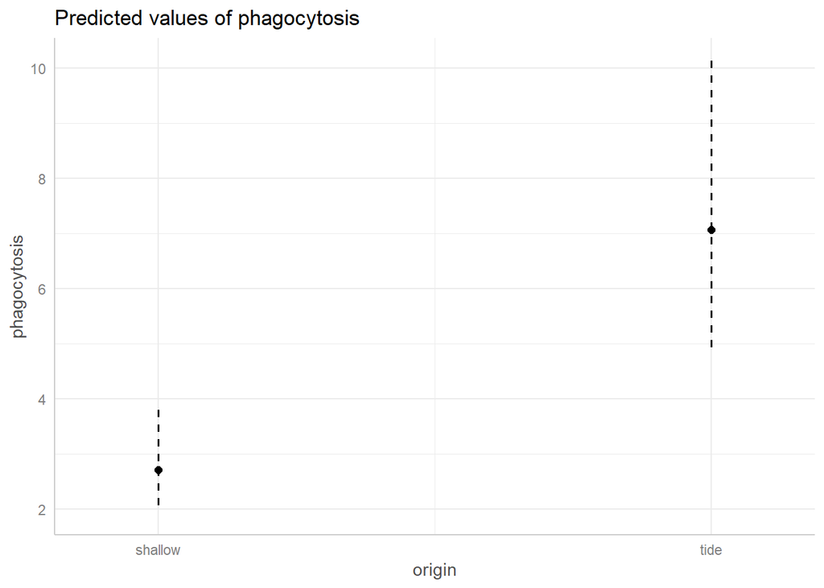

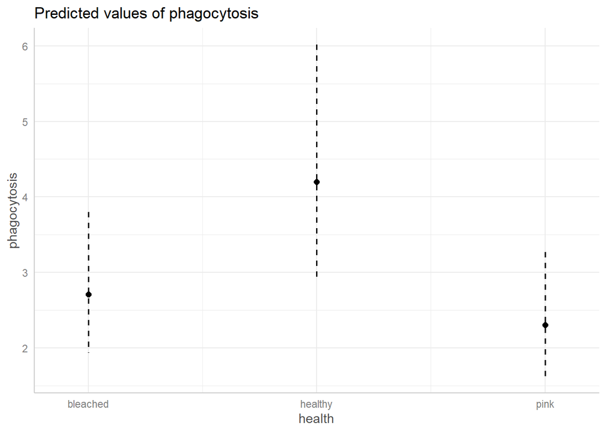

```r
ggpredict(mod_fago_gama) %>% plot()
```